# Post doc meeting

Last update: 18 May 2022

## Why do we want to assess community changes ?

- Global changes have affect a tremendous effect communities
- Understanding assembly and disassembly rules
- Give a more complex and complete picture of what is going on ?

## Link between different facets of biodiversity

- Species richness:
  - Evenness / richness: (+) (Soininen, Passy, and Hillebrand 2012)
  - FDiv / richness: (+) (Mouchet et al. 2010)
  - FEve / richness: (O) (Mouchet et al. 2010) … to complete

## Space for time substitution

- Facet relationships come from space-for-time substitution
- Assume an homology between variation in space and variation in time

## Research gaps

- Few facets of biodiversity have been documented in time
- Relationships between facet temporal trends are even more scarce

## Research Questions

1. How do communities change through time ?
   - Richness, Evenness, Disparity
2. How to species characteristics explains community change ?
   - Life history traits, trophic position, …
   - Make a typology of declining and increasing species

## How to measure biodiversity through time ?

- Three index categories (Daly, Baetens, and De Baets 2018):
  1. Richness: number of species, number of individuals
  - \(S\), \(N\)
  1. Evenness: distribution of species abundance
  - vector of species relative abundances \(p = (p_1, ..., p_S)\)
  1. Disparity: between species, i.e. functional, taxonomic, phylogenetic, …

## How do composition change ?

- Species exchange index: (Hillebrand et al. 2018)
  - \(SER_r = \dfrac{S_{imm} + S_{lost}}{S_{tot}}\) based on presence absence
  - \(SER_a = \dfrac{\sum_i (p_i - p^{\prime}_i)^2}{\sum_i p_i^2 + \sum_i p^{\prime2}_i - \sum_i p_i p^{\prime}_i}\)
- Abundance based (between two time steps)(Shimadzu, Dornelas, and Magurran 2015):
  - considers a turnover metric decomposed based either on total abundance or species composition.

## To keep in mind

We want to measure dimension of biodiversity that are not related to each other.

- One measure reflecting richness
- One measure reflecting composition

## Multi-site version of community change

- Based on deviance: (Baeten et al. 2014)
  - Omnipresent and rare species have the same contribution to the heterogeneity in community composition

[figure not shown]

Figure 1

- \(D_i = -2n [p_i\log(p_i) + (1-p_i)\log(1-p_i)]\)
- We can look at the contribution of each species (convergence or divergence)

## Population

## LPI

- \(d_{i,j,t} = \log_{10}(\dfrac{N_{i,j,t}}{N_{i,j,t-1}}) = \log_{10}N_{i,j,t} - \log_{10}N_{i,j,t-1}\)

\(i\): a population \(j\): a species \(t\): a time step

- Trends by species: \(d_{j,t} = \dfrac{1}{n}\sum_{i = 1}^{n} d_{i,j,t}\)
- LPI: \(I_{j, t} = I_{j, t - 1} 10^{d_{j,t}}\), \(I_0 = 1\)
- Confidence interval: bootstrap on the selection of the \(n_j\) populations by species.

## Computation of the LPI

- Missing values:
  - imputed by log linear interpolation: \(N_t = N_p (\dfrac{N_s}{N_p})^{\dfrac{t-s}{s-p}}\)
  - imputed by a GAM
- Dealing with 0:
  - add a small quantity to 0
  - GAM get mostly rid of it

## Properties of the LPI

- Pro:
  - Proportional changes, low change in absolute abundance in a rare species can lead a big change in the geometric mean
  - No biais for detectability variation between species
  - no differences if units are abundance, biomass, density
  - combine trends of really different survey
- Con:
  - no differences if units are abundance, biomass, density
  - combine trends of really different survey

## Methods

## Selection of sites and protocol

- Homogeneous protocol
- Keep sampling within 3 months relative to the median month of sampling of the site
- Sites followed at least 10 years

## Community metrics

- Raw metrics:
  - Species richness, total abundance
  - Shannon (H), Simpson
  - Evenness: pielou \(J = \dfrac{H}{log(S)}\)
- Coverage based metrics (Chao and Jost 2012):
  - Richness, Shannon, Simpson

## Community metrics

- Turnover (relative to first year of sampling):
  - Jaccard: \(\dfrac{S_c}{S_{tot}}\)
  - Chao and Horn (cf Dornelas et al. (2014)):
  - Hillebrand: \(SER_a = \dfrac{\sum_i (p_i - p^{\prime}_i)^2}{\sum_i p_i^2 + \sum_i p^{\prime2}_i - \sum_i p_i p^{\prime}_i}\)
  - Total (Hillebrand based on p/a): \(T = \dfrac{S_a + S_d}{S_{tot}}\)
  - Appearance: \(A = \dfrac{S_a}{S_{tot}}\)
  - Disappearance: \(D = \dfrac{S_d}{S_{tot}}\)

## Temporal trends

- By site:
  - \(Y_i = \alpha + \Beta X_i + \epsilon_i\)
    - \(X_i\): year
    - \(\alpha\): “year 0”
    - \(\Beta\): temporal trends
- Modelling the trends of all sites at once: to discuss later
  - problems: time to convergence, RAM of my laptop (spaMM, INLA)

## Comparison Chao classic indices

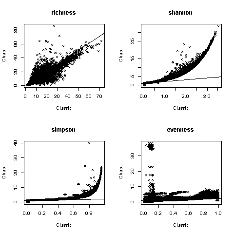

## Turnover similarity

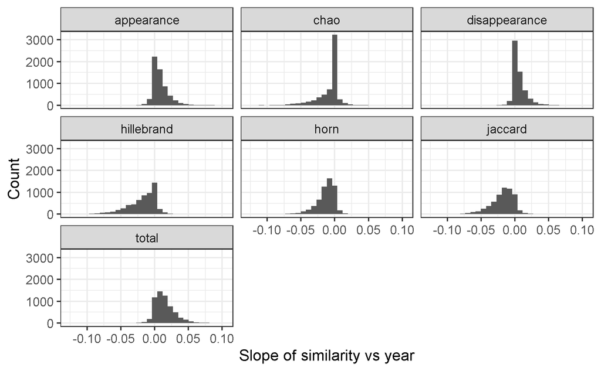

## Trends

## Species richness

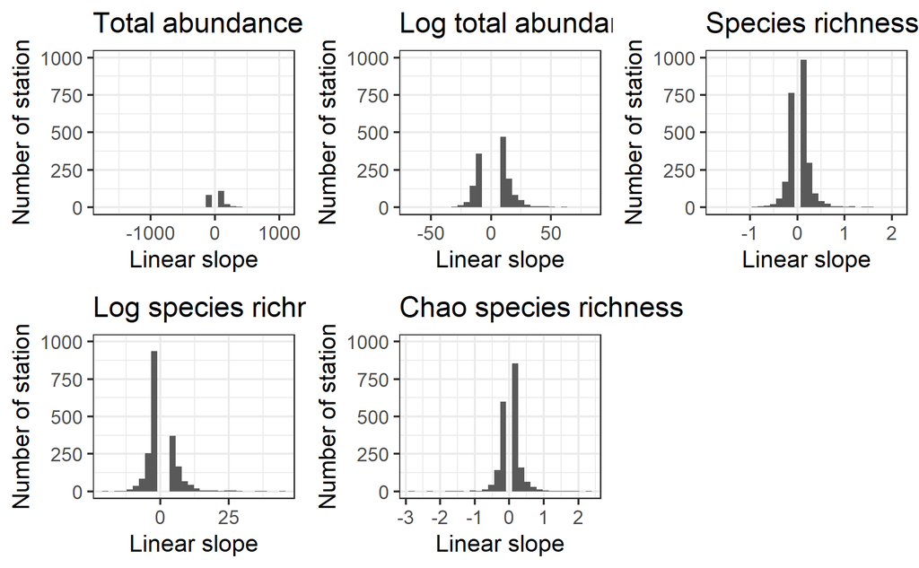

## Hill numbers & evenness

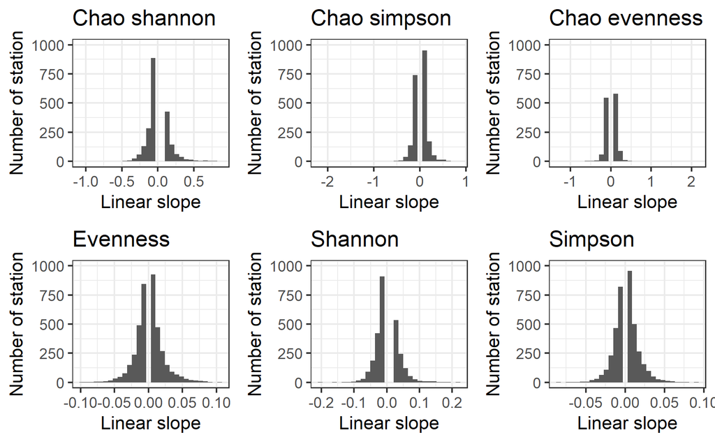

## Turnover

Mean jaccard slope: -0.02 (-0.01 in Dornelas et al. (2014))

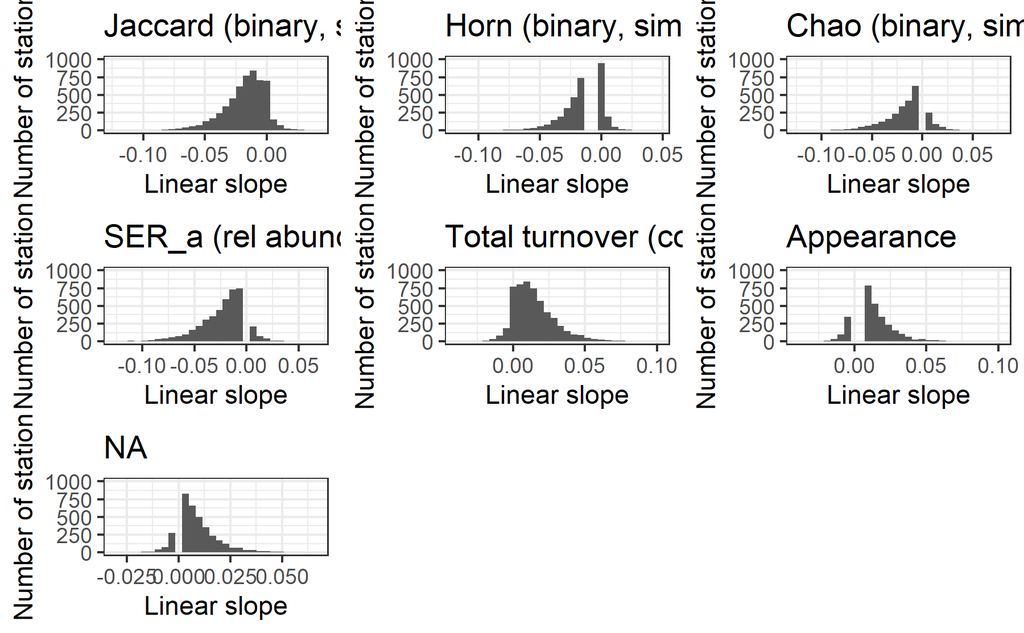

## Trajectories classification

| response | stable | increase | decrease |
| --- | --- | --- | --- |
| total_abundance | 83.1% | 9.5% | 7.4% |
| log_total_abundance | 80.8% | 11.4% | 7.7% |
| species_nb | 80.2% | 12.0% | 6.2% |
| log_species_nb | 78.9% | 11.4% | 5.8% |
| chao_richness | 82.5% | 10.0% | 6.4% |
| chao_shannon | 80.5% | 10.0% | 6.2% |
| chao_simpson | 81.7% | 8.6% | 6.4% |
| chao_evenness | 85.4% | 6.0% | 5.4% |
| jaccard | 68.3% | 0.5% | 29.5% |
| horn | 69.8% | 0.5% | 28.1% |
| chao | 70.6% | 2.7% | 12.8% |
| hillebrand | 72.6% | 0.5% | 25.8% |
| total | 66.6% | 28.2% | 0.2% |
| appearance | 68.0% | 21.3% | 0.4% |
| disappearance | 62.3% | 16.3% | 0.1% |
| evenness | 82.8% | 7.2% | 6.8% |
| shannon | 79.9% | 10.3% | 6.7% |
| simpson | 81.7% | 8.7% | 6.4% |
| jaccard_dis | 65.6% | 29.2% | 0.1% |
| nestedness | 80.2% | 13.9% | 0.4% |
| turnover | 56.4% | 13.5% | 0.1% |

## Link between temporal trends

[figure not shown]

## Next steps

## Biodiversity

- Continue to explore the relationships between temporal trends
- Neutral model for turnover [untb package](https://cran.r-project.org/web/packages/untb/index.html) (Dornelas et al. 2014)
- Functional composition:
  - Trophic level
  - CTI
  - Life history
- Phylogeny

## Environment

- Temperature
- Land-use

## Modelling

- Test (Illinois or France) global modelling of trajectories instead of site by site
- Think about cluster availability for heavy modelling

## References

Baeten, Lander, David I. Warton, Hans Van Calster, Pieter De Frenne, Gorik Verstraeten, Dries Bonte, Markus Bernhardt-Römermann, et al. 2014. “A Model-Based Approach to Studying Changes in Compositional Heterogeneity.” *Methods in Ecology and Evolution* 5 (2): 156–64. https://doi.org/10.1111/2041-210X.12137.

Barnagaud, Jean-Yves, Pierre Gaüzère, Benjamin Zuckerberg, Karine Princé, and Jens-Christian Svenning. 2017. “Temporal Changes in Bird Functional Diversity Across the United States.” *Oecologia* 185 (4): 737–48. https://doi.org/10.1007/s00442-017-3967-4.

Chao, Anne, and Lou Jost. 2012. “Coverage-Based Rarefaction and Extrapolation: Standardizing Samples by Completeness Rather Than Size.” *Ecology* 93 (12): 2533–47. https://doi.org/10.1890/11-1952.1.

Daly, Aisling, Jan Baetens, and Bernard De Baets. 2018. “Ecological Diversity: Measuring the Unmeasurable.” *Mathematics* 6 (7): 119. https://doi.org/10.3390/math6070119.

Dornelas, Maria, Nicholas J. Gotelli, Brian McGill, Hideyasu Shimadzu, Faye Moyes, Caya Sievers, and Anne E. Magurran. 2014. “Assemblage Time Series Reveal Biodiversity Change but Not Systematic Loss.” *Science* 344 (6181): 296–99. https://doi.org/10.1126/science.1248484.

Hillebrand, Helmut, Bernd Blasius, Elizabeth T. Borer, Jonathan M. Chase, John A. Downing, Britas Klemens Eriksson, Christopher T. Filstrup, et al. 2018. “Biodiversity Change Is Uncoupled from Species Richness Trends: Consequences for Conservation and Monitoring.” *Journal of Applied Ecology* 55 (1): 169–84. https://doi.org/https://doi.org/10.1111/1365-2664.12959.

Klink, Roel van, Diana E. Bowler, Konstantin B. Gongalsky, Ann B. Swengel, Alessandro Gentile, and Jonathan M. Chase. 2020. “Meta-Analysis Reveals Declines in Terrestrial but Increases in Freshwater Insect Abundances.” *Science* 368 (6489): 417–20. https://doi.org/10.1126/science.aax9931.

Mouchet, Maud A., Sébastien Villéger, Norman W. H. Mason, and David Mouillot. 2010. “Functional Diversity Measures: An Overview of Their Redundancy and Their Ability to Discriminate Community Assembly Rules.” *Functional Ecology* 24 (4): 867–76. https://doi.org/10.1111/j.1365-2435.2010.01695.x.

Shimadzu, Hideyasu, Maria Dornelas, and Anne E. Magurran. 2015. “Measuring Temporal Turnover in Ecological Communities.” Edited by Robert B. O’Hara. *Methods in Ecology and Evolution* 6 (12): 1384–94. https://doi.org/10.1111/2041-210X.12438.

Soininen, Janne, Sophia Passy, and Helmut Hillebrand. 2012. “The Relationship Between Species Richness and Evenness: A Meta-Analysis of Studies Across Aquatic Ecosystems.” *Oecologia* 169 (3): 803–9. https://doi.org/10.1007/s00442-011-2236-1.

Vellend, Mark, Lander Baeten, Isla H. Myers-Smith, Sarah C. Elmendorf, Robin Beauséjour, Carissa D. Brown, Pieter De Frenne, Kris Verheyen, and Sonja Wipf. 2013. “Global Meta-Analysis Reveals No Net Change in Local-Scale Plant Biodiversity over Time.” *Proceedings of the National Academy of Sciences* 110 (48): 19456–59.